# Experiment 1 Timing Assessment

Dave Braun

July 3, 2019

This document is dedicated to estimating the trial thresholds for Experiment 1. I ran through a short version of the study myself, and I’m going to use my timing information to draw rough estimates about what the trial thresholds should be.

Unlike previous rVTS studies I’ve run on MTurk, timing shouldn’t depend much on performance, so I expect the between-subject variability in finishing time to be low.

## Cued Task Switching

We need to know how many trials of cued task switching equals about five minutes.

```r
d <- read.csv('../../../data/pracCued.csv')
head(d)
```

```
##   cuedRunTime windowWidth       workerId redTask
## 1      122895        1870 A2TWV7CJ6WS03O     par
## 2      122895        1870 A2TWV7CJ6WS03O     par
## 3      122895        1870 A2TWV7CJ6WS03O     par
## 4      122895        1870 A2TWV7CJ6WS03O     par
## 5      122895        1870 A2TWV7CJ6WS03O     par
## 6      122895        1870 A2TWV7CJ6WS03O     par
##                            curId screenHeight blueTask             curTime
## 1 3KKG4CDWKJIFSH7DQNNAX20PP2Q94T         1080      mag 08/07/2019@16:21:26
## 2 3KKG4CDWKJIFSH7DQNNAX20PP2Q94T         1080      mag 08/07/2019@16:21:26
## 3 3KKG4CDWKJIFSH7DQNNAX20PP2Q94T         1080      mag 08/07/2019@16:21:26
## 4 3KKG4CDWKJIFSH7DQNNAX20PP2Q94T         1080      mag 08/07/2019@16:21:26
## 5 3KKG4CDWKJIFSH7DQNNAX20PP2Q94T         1080      mag 08/07/2019@16:21:26
## 6 3KKG4CDWKJIFSH7DQNNAX20PP2Q94T         1080      mag 08/07/2019@16:21:26
##   windowHeight    phase
```

[output cut: 27 more lines]

Creating an estimate of time by adding RT on to trial count weighted by the 500 RSI (ie, `totalTime <- sum(RT) + nTrials * 500)`

```r
totalTime <- (sum(d$rt) + nrow(d) * 500) / 1000
print(paste(nrow(d), 'trials.'))
```

```
## [1] "30 trials."
```

```r
print(paste(round(totalTime,2), 'seconds.'))
```

[output not shown]

```r
targetTrials <- (30*300) / 33.91
print(paste(round(targetTrials, 2), 'trials will be needed'))
```

```
## [1] "265.41 trials will be needed"
```

Seems like a bit much, but maybe that is the number of trials it’ll take. I might tone this down to 3 min to leave more time for the important data collection.

### Estimating from previous MTurk cued task data

I remembered I had run cued task switching on MTurk in the fall of 2018. Let’s see whether trial estimates from that data converge with mine from above.

I dug up the old html scripts for that study and saw that the cued phase ran for 160 trials. There’s also a variable called `finishTime`, which is the time at the end of the phase subtracted from their landing on the cued html. So this time will include time spent watching instructions, which was 3 min 14 sec.

```r
d <- read.csv('../../../../../../../switch_experiments/mturk_studies/foraging/data/cued_full.csv')
colnames(d) <- tolower(colnames(d))
head(d)
```

```
##   x finishtime screen_width window_height       workerid window_width
## 1 0     645276         1366           708 A1NBX7UHTU5CKG          608
## 2 1     645276         1366           708 A1NBX7UHTU5CKG          608
## 3 2     645276         1366           708 A1NBX7UHTU5CKG          608
## 4 3     645276         1366           708 A1NBX7UHTU5CKG          608
## 5 4     645276         1366           708 A1NBX7UHTU5CKG          608
## 6 5     645276         1366           708 A1NBX7UHTU5CKG          608
##                            curid             curtime counterbalance_order
## 1 33JKGHPFYDEGL90DX169N1EH338NMI 11/10/2018@06:56:16           cued_first
## 2 33JKGHPFYDEGL90DX169N1EH338NMI 11/10/2018@06:56:16           cued_first
## 3 33JKGHPFYDEGL90DX169N1EH338NMI 11/10/2018@06:56:16           cued_first
## 4 33JKGHPFYDEGL90DX169N1EH338NMI 11/10/2018@06:56:16           cued_first
## 5 33JKGHPFYDEGL90DX169N1EH338NMI 11/10/2018@06:56:16           cued_first
## 6 33JKGHPFYDEGL90DX169N1EH338NMI 11/10/2018@06:56:16           cued_first
##                                                                                                useragent
```

[output cut: 27 more lines]

```r
d$finishTimeMins <- (d$finishtime + 1000) / 1000 / 60
```

```r
d <- d %>%
  group_by(workerid) %>%
  summarize(dummy = n()) %>%
  mutate(subject = 1:(nrow(.))) %>%
  select(-dummy) %>%
  inner_join(d)
```

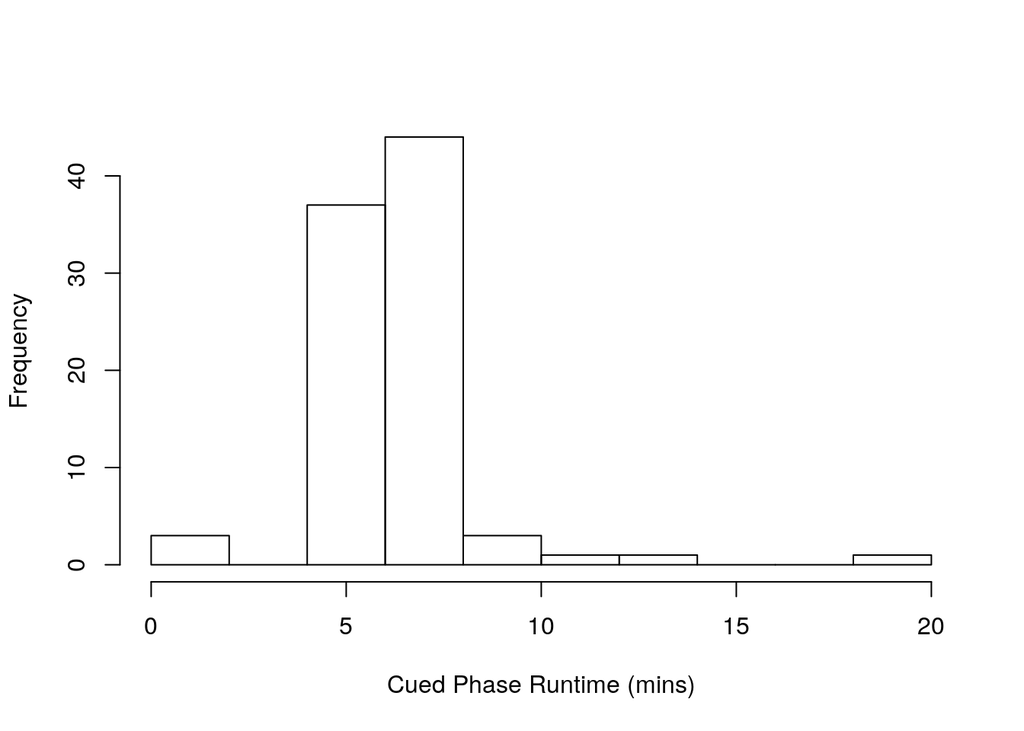

```r
s <- d %>%
  group_by(subject) %>%
  summarize(finishTimeMins = mean(finishTimeMins))

hist(s$finishTimeMins, xlab = 'Cued Phase Runtime (mins)', main = '')
```

```r
print(c('Mean Runtime (mins)' = mean(s$finishTimeMins), 'SD Runtime (mins)' = sd(s$finishTimeMins)))
```

```
## Mean Runtime (mins)   SD Runtime (mins)
##            6.300893            1.992548
```

I’ll do another summary calculating runtime from RTs and CTIs / RCIs.

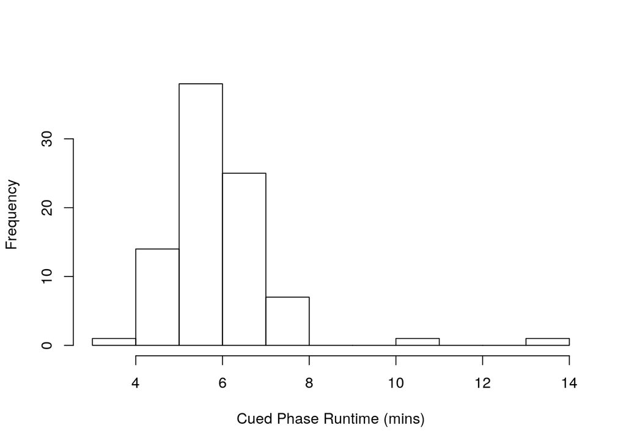

```r
s <- d %>%
  group_by(subject) %>%
  summarize(sumRt = sum(rt), count = n())

badSubjects <- s[s$count < 160, ]$subject

s <- s[!(s$subject %in% badSubjects),]

s$runTimeMins <- (s$sumRt + (1100 * 160)) / 1000 / 60
hist(s$runTimeMins, xlab = 'Cued Phase Runtime (mins)', main = '')
```

```r
print(c('Mean Runtime (mins)' = mean(s$runTimeMins), 'SD Runtime (mins)' = sd(s$runTimeMins)))
```

```
## Mean Runtime (mins)   SD Runtime (mins)
##            5.891275            1.293627
```

This suggests to me that 160 trials puts us right around the 5 min mark on average. I’ll start there for the pilots then.

## Demand Selection Task

```r
d <- read.csv('../../../data/dst.csv')
head(d)
```

```
##   windowWidth       workerId redTask                          curId
## 1        1870 A2TWV7CJ6WS03O     par 3KKG4CDWKJIFSH7DQNNAX20PP2Q94T
## 2        1870 A2TWV7CJ6WS03O     par 3KKG4CDWKJIFSH7DQNNAX20PP2Q94T
## 3        1870 A2TWV7CJ6WS03O     par 3KKG4CDWKJIFSH7DQNNAX20PP2Q94T
## 4        1870 A2TWV7CJ6WS03O     par 3KKG4CDWKJIFSH7DQNNAX20PP2Q94T
## 5        1870 A2TWV7CJ6WS03O     par 3KKG4CDWKJIFSH7DQNNAX20PP2Q94T
## 6        1870 A2TWV7CJ6WS03O     par 3KKG4CDWKJIFSH7DQNNAX20PP2Q94T
##   screenHeight blueTask             curTime windowHeight phase
## 1         1080      mag 08/07/2019@16:26:48          675   dst
## 2         1080      mag 08/07/2019@16:26:48          675   dst
## 3         1080      mag 08/07/2019@16:26:48          675   dst
## 4         1080      mag 08/07/2019@16:26:48          675   dst
## 5         1080      mag 08/07/2019@16:26:48          675   dst
## 6         1080      mag 08/07/2019@16:26:48          675   dst
##                                                                      userAgent
```

[output cut: 41 more lines]

Looks like we have a block time saved in the data. I’ll just summarize over that.

```r
d %>%
  summarize('Block Time' = mean(blockTime), 'Block Time SD' = sd(blockTime))
```

[output not shown]

```r
d %>%
  filter(block == 1) %>%
  summarize('Trial Count Per Block' = n())
```

```
##   Trial Count Per Block
## 1                    60
```

```r
targetPerBlock <- (25 * 60) / 8
print(paste(targetPerBlock, 'seconds per block is what we want.'))
```

```
## [1] "187.5 seconds per block is what we want."
```

```r
targetTrials <- (60 * 187.5) / 33
print(paste("We'll want", round(targetTrials), 'trials per block.'))
```

```
## [1] "We'll want 341 trials per block."
```